# Anomaly Detection

# Anomaly Detection

```r
# order by date so that anomalize function can work better
df1 <- dplyr::arrange(df, Date)

# convert to tibble
sales <- as_tibble(df1)

# convert to tibble time
sales1 <- as_tbl_time(sales, index = Date)
class(sales1)
```

```
## [1] "tbl_time"   "tbl_df"     "tbl"        "data.frame"
```

The R ‘anomalize’ package enables a workflow for detecting anomalies in data. The main functions are time_decompose(), anomalize(), and time_recompose().

```r
# checking for anomalies
df_anomalized <- sales1 %>%
  as_period("daily") %>%
  time_decompose(Sales) %>%
  anomalize(remainder) %>%
  time_recompose()
```

```
## frequency = 7 days
```

```
## trend = 30 days
```

```r
df_anomalized %>% glimpse()
```

```
## Rows: 89
## Columns: 10
## $ Date          <date> 2020-01-01, 2020-01-02, 2020-01-03, 2020-01-04, 2020-01~
## $ observed      <dbl> 457.4430, 44.5935, 367.5525, 75.7785, 548.9715, 939.5400~
## $ season        <dbl> 71.60220, -137.93561, -32.93877, -73.88690, -17.91742, 1~
## $ trend         <dbl> 296.3521, 298.8125, 301.2728, 303.7331, 307.0337, 310.33~
## $ remainder     <dbl> 89.488658, -116.283358, 99.218460, -154.067738, 259.8551~
## $ remainder_l1  <dbl> -1131.823, -1131.823, -1131.823, -1131.823, -1131.823, -~
## $ remainder_l2  <dbl> 1168.64, 1168.64, 1168.64, 1168.64, 1168.64, 1168.64, 11~
## $ anomaly       <chr> "No", "No", "No", "No", "No", "No", "No", "No", "No", "N~
## $ recomposed_l1 <dbl> -763.8688, -970.9462, -863.4891, -901.9769, -842.7068, -~
## $ recomposed_l2 <dbl> 1536.594, 1329.517, 1436.974, 1398.486, 1457.756, 1582.0~
```

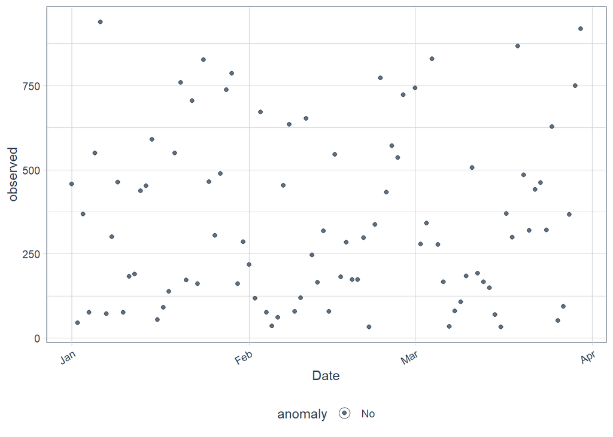

```r
#We can then visualize the anomalies using the plot_anomalies() function.

df_anomalized %>% plot_anomalies(ncol = 3, alpha_dots = 0.75)
```

Adjusting Trend and Seasonality With anomalize, it’s simple to make adjustments because everything is done with a date or DateTime information so you can intuitively select increments by time spans that make sense (e.g. “5 minutes” or “1 month”).

First, notice that a frequency and a trend were automatically selected for us. This is by design. The arguments frequency = “auto” and trend = “auto” are the defaults. We can visualize this decomposition using plot_anomaly_decomposition().

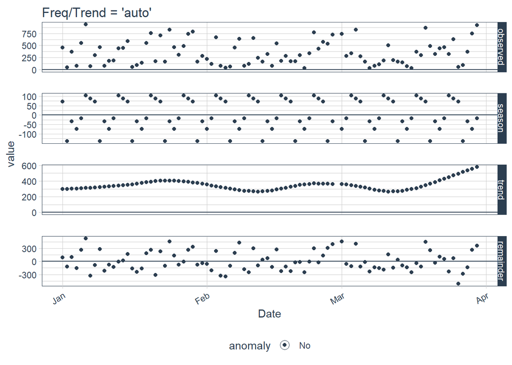

```r
p1 <- df_anomalized %>%
    plot_anomaly_decomposition() +
    ggtitle("Freq/Trend = 'auto'")
p1
```

Adjusting Local Parameters Local parameter adjustment is performed by tweaking the in-function parameters. Below we adjust trend = “2 weeks” which makes for a quite overfit trend.

```r
p2 <- sales1  %>%
  as_period("daily") %>%
    time_decompose(Sales,
                   frequency = "auto",
                   trend     = "14 days") %>%
    anomalize(remainder) %>%
    plot_anomaly_decomposition() +
    ggtitle("Trend = 2 Weeks (Local)")
```

```
## frequency = 7 days
```

```
## trend = 14 days
```

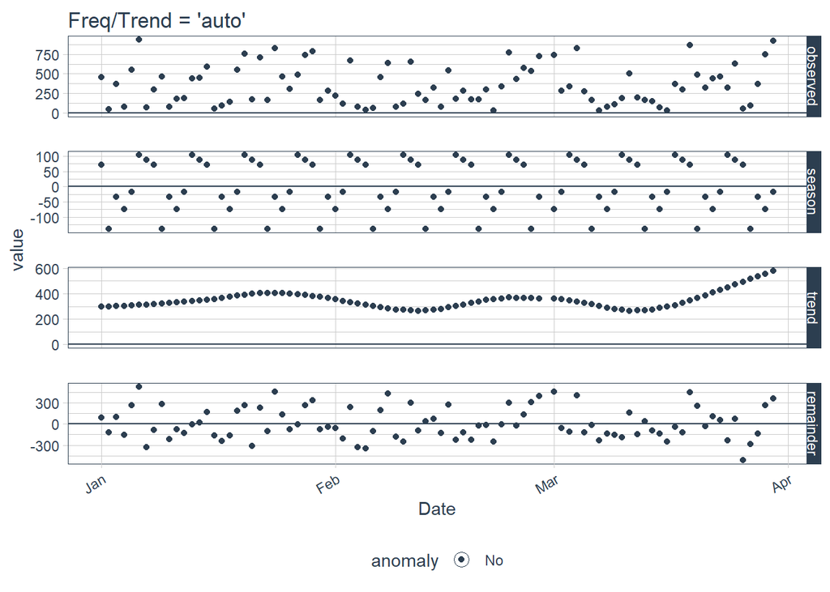

```r
# Show plots
p1
```

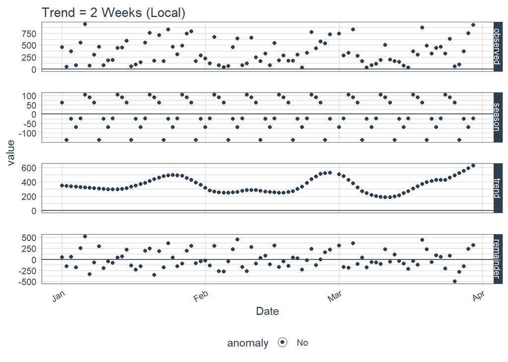

```r
p2
```

Alpha

We can adjust alpha, which is set to 0.05 by default. By default, the bands just cover the outside of the range. If we decrease alpha, it increases the bands making it more difficult to be an outlier.

```r
p4 <- sales1 %>%
  as_period("daily") %>%
    time_decompose(Sales) %>%
    anomalize(remainder, alpha = 0.05, max_anoms = 0.2) %>%
    time_recompose() %>%
    plot_anomalies(time_recomposed = TRUE) +
    ggtitle("alpha = 0.05")
```

```
## frequency = 7 days
```

```
## trend = 30 days
```

[output not shown]

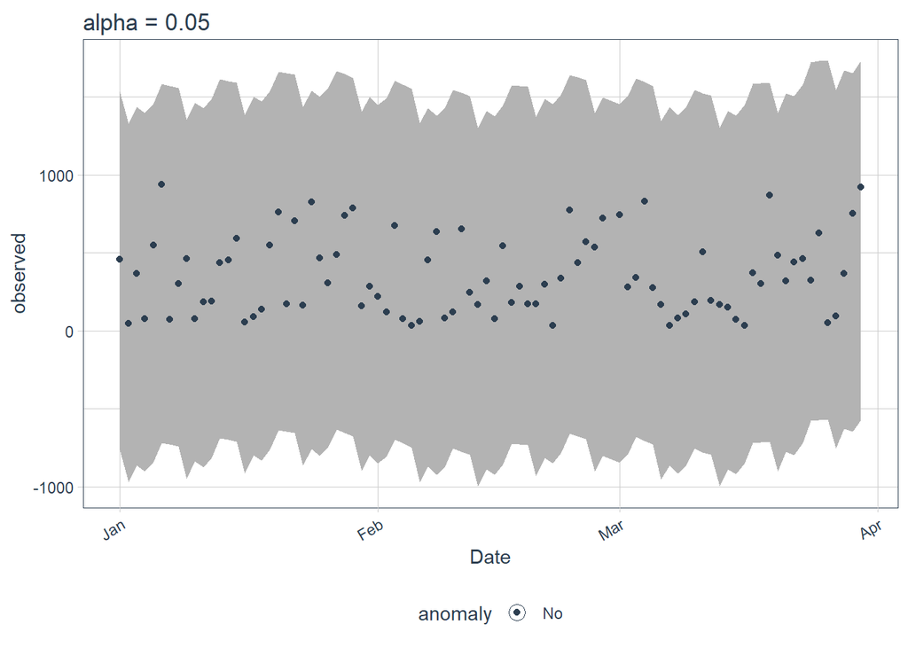

```r
p4
```

From the above plot we can see that none of the points have been marked as outliers, we will therefore set our alpha to a larger value like 0.2 and see the results.

```r
p5 <- sales1 %>%
  as_period("daily") %>%
    time_decompose(Sales) %>%
    anomalize(remainder, alpha = 0.2, max_anoms = 0.2) %>%
    time_recompose() %>%
    plot_anomalies(time_recomposed = TRUE) +
    ggtitle("alpha = 0.2")
```

```
## frequency = 7 days
```

```
## trend = 30 days
```

[output not shown]

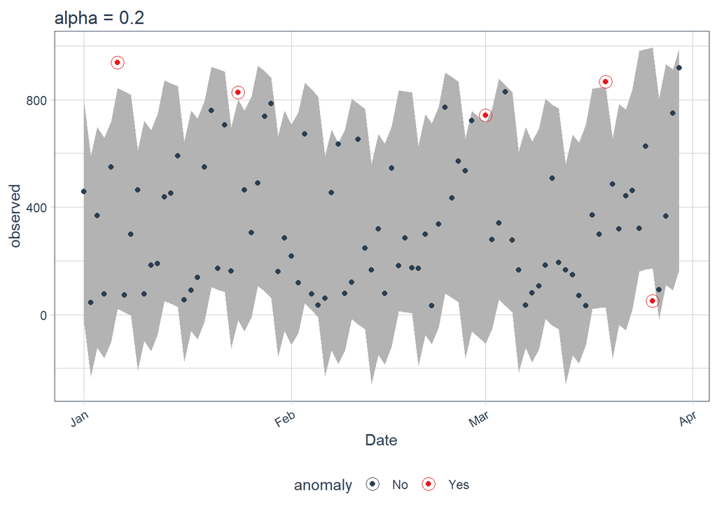

```r
p5
```

We can see that some points have now been marked as outliers.

Max Anoms The max_anoms parameter is used to control the maximum percentage of data that can be an anomaly. Let’s adjust alpha = 0.3 so pretty much anything is an outlier. Now let’s try a comparison between max_anoms = 0.2 (20% anomalies allowed) and max_anoms = 0.05 (5% anomalies allowed).

```r
p6 <- sales1 %>%
  as_period("daily") %>%
    time_decompose(Sales) %>%
    anomalize(remainder, alpha = 0.3, max_anoms = 0.2) %>%
    time_recompose() %>%
    plot_anomalies(time_recomposed = TRUE) +
    ggtitle("20% Anomalies")
```

```
## frequency = 7 days
```

```
## trend = 30 days
```

```r
p7 <- sales1 %>%
  as_period("daily") %>%
    time_decompose(Sales) %>%
    anomalize(remainder, alpha = 0.3, max_anoms = 0.05) %>%
    time_recompose() %>%
    plot_anomalies(time_recomposed = TRUE) +
    ggtitle("5% Anomalies")
```

```
## frequency = 7 days
## trend = 30 days
```

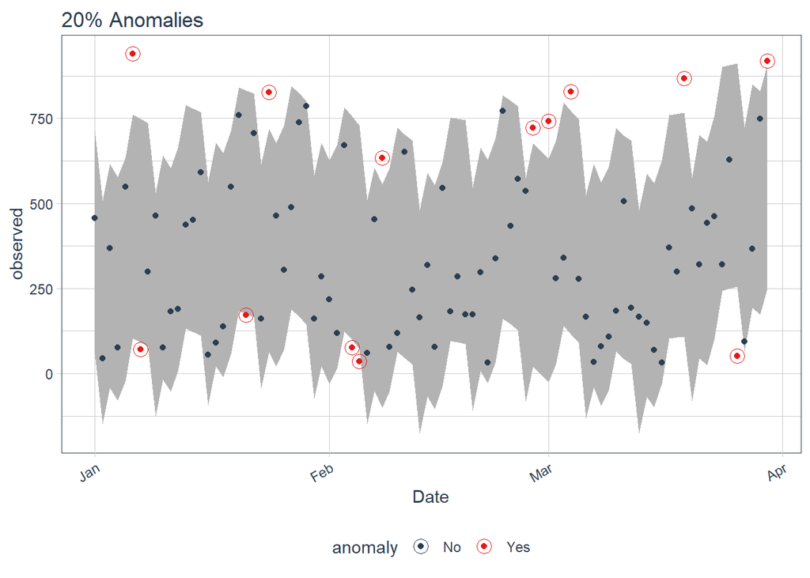

```r
p6
```

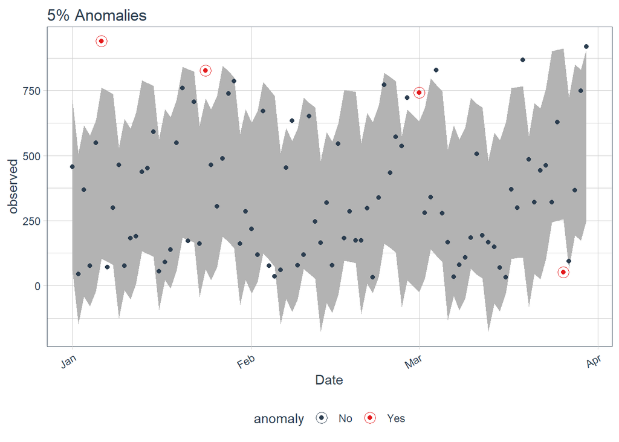

```r
p7
```

From the above plots we can see that when we adjust our max anoms parameter, the number of points considered as anomalies changes too, for instance, when our max-anoms is set to 0.2, 13 points are marked as anomalies but when it is set to 0.05, only 4 points are marked as anomalies.

# Conclusion

From the analysis above we can see that at first glance our dataset does not have any obvious anomalies, we had to tweak our parameters to identify points that can be considered as anomalies.

To add more to our anomaly detection we can create an interactive anomaly plot Using the ‘timetk’ package. timetk is a ToolKit for working with Time Series in R, to plot, wrangle, and feature engineer time series data for forecasting and machine learning prediction.

Interactive Anomaly Visualization Here, timetk’s plot_anomaly_diagnostics() function makes it possible to tweak some of the parameters on the fly.

```r
library(timetk)
```

```r
sales1 %>% timetk::plot_anomaly_diagnostics(Date,Sales, .facet_ncol = 2)
```

[output not shown]

[output not shown]

[interactive chart not shown]